# LAB_1

Bartosz Łabiszak, Zakład Ekologii Roślin i Ochrony Środowiska

# Genomika Populacyjna: Wykrywanie Doboru Naturalnego - geny kandydackie

## Wstęp

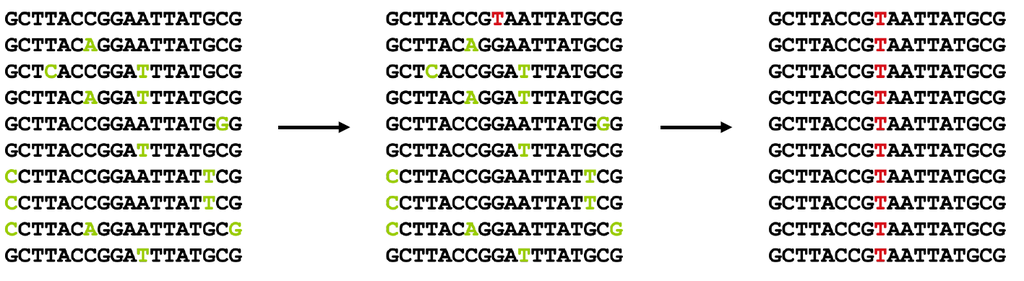

**Informacja o zaliczeniu**

Warunkiem zaliczenia ćwiczeń jest **terminowe wysłanie opracowanych protokołów z ćwiczeń**.

Termin przesłania kompletu protokołów to **15.06.2025**. W nazwie pliku proszę podać swoje **imię i nazwisko**.

**1. Opis danych do wykonania ćwiczeń**

Materiał do ćwiczeń stanowią drzewa pochodzących z populacji zaznaczonych punktami i symbolami na poniższej mapie oraz reprezentujących europejski zasięg występowania sosny zwyczajnej (zaznaczony kolorem szarym).

Rozpoznanie zmienności neutralnych markerów wykazały jednorodne tło genetyczne na znacznym obszarze. Populacje z różnych części zasięgu wykazują jednak różnice wynikające z lokalnej adaptacji do odmiennych warunków życia w gradiencie szerokości geograficznej.

Analiza populacji z krańców zasięgu, poddanych odmiennej presji selekcyjnej (Subpopulacja północna zawiera 20 prób z czterech populacji fińskich : F1,F2, F3 i F4 a południowa 20 prób z Bałkanów : B, S i G pozwoli na wykrycie molekularnego podłoża adaptacji do warunków środowiskowych.

Dobór naturalny pozostawia charakterystyczne ślady w zmienności genetycznej. W populacji w której nie działa dobór, różnorodność sekwencji DNA wynika z założeń opartych na modelu, w którym jedyne znaczenie ma równowaga między mutacjami a dryfem genetycznym. Dobór może jednak **zmieniać częstości alleli**, **zmniejszać lub zwiększać różnorodność genetyczną** oraz powodować **korelacje (nierównowagę sprzężeń - LD) pomiędzy miejscami zmiennymi**.

Wykorzystując dane sekwencyjne **trzech genów kandydackich** na poziomie populacji ogólnej i subpopulacji oraz wykonując analizy ich zmienności genetycznej, sprawdź, który z genów jest poddany działaniu doboru naturalnego.

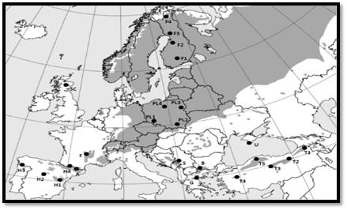

## Wymagane pakiety

Najpierw ładujemy wymagane pakiety R i wczytujemy dane sekwencyjne. Korzystamy z bibliotek **ape**, **adegenet**, **hierfstat** i **pegas poppr** do pracy z danymi sekwencyjnymi oraz obliczania podstawowych statystyk zmienności. Dodatkowo potrzebne będą pakiety: **ggplot2** i **reshape2** (do wizualizacji danych i ich przekształcania), **nls2** (do regresji nieliniowej) oraz zbiór pakietów **tidyverse** (do ogólnej manipulacji danymi). Upewnij się, że wszystkie te pakiety są zainstalowane.

```r
# Load necessary libraries
library(ape)
library(pegas)
library(rehh)
library(adegenet)
library(hierfstat)
library(ggplot2)
library(tidyverse)
library(reshape2)
library(nls2)
library(poppr)
library(dplyr)
```

Mamy trzy pliki FASTA: `"Gen_1.fasta"`, `"Gen_2.fasta"`, `"Gen_3.fasta"` Na początek wczytamy tylko jeden plik – **Gen_1**. Następnie należy powtórzyć wszystkie analizy dla pozostałych dwóch genów (**Gen_2** i **Gen_3**). Każdy plik FASTA zawiera 40 sekwencji: 20 z regionu północnego (**North**) i 20 z regionu południowego (**South**). Nazwy sekwencji zaczynają się odpowiednio od **N** lub **S**, co wskazuje na ich pochodzenie. Sekwencje dzielimy na trzy zbiory: pełny zbiór **(total)** oraz dwa zbiory specyficzne dla subpopulacji – **North** i **South**.

## Obliczanie podstawowych statystyk zmienności

Obliczymy podstawowe statystyki zmienności dla każdego genu i każdej subpopulacji:

- **N** – liczba badanych sekwencji.
- **L** – długość sekwencji (bp).
- **S** – liczba miejsc zmiennych (polimorficznych).
- **Sg** – liczba unikaowych miejsc polimorficznych (singletons).
- **π (pi)** – zróżnicowanie nukleotydowe.
- **Nh** – liczba haplotypów.
- **Hd** – zróżnicowanie haplotypowe.

Obliczenia przeprowadzimy osobno dla każdego genu w trzech grupach: (a) dla całej populacji (**total**), (b) dla populacji północnej (**North**),  
(c) dla populacji południowej (**South**).

```r
# Define file names
fasta_file <- "Gen_1.fasta"

# Use ape::read.dna to read FASTA as DNA binary (DNAbin) format

dna <- read.dna(fasta_file, format = "fasta")
gene_name <- sub("\\.fasta$", "", fasta_file)

seq_names <- rownames(dna)
# Group indices for North (N) and South (S) populations
north_idx <- grep("^N", seq_names)    # names starting with N
south_idx <- grep("^S", seq_names)    # names starting with S

# Create subsets: total, north, south
dna_tot <- dna  # all sequences
dna_north <- dna[north_idx, ]
dna_south <- dna[south_idx, ]


# List of DNAbin objects and their corresponding population names
dna_list <- list(total = dna_tot, north = dna_north, south = dna_south)

# Function to compute diversity statistics for a given DNA dataset
compute_diversity_stats <- function(dna, gene_name, pop_name) {
  n_seq <- nrow(dna)              # Number of sequences (N)
  seq_length <- ncol(dna)         # Sequence length (L)
  seg_sites <- seg.sites(dna)     # Indices of segregating sites
  S <- length(seg_sites)          # Number of segregating sites

  # Compute singleton sites (Sg)
  Sg <- 0
  if (S > 0) {
    dna_matrix <- as.character(as.matrix(dna))
    for (site in seg_sites) {
      alleles <- dna_matrix[, site]
      alleles <- alleles[alleles %in% c("a", "c", "g", "t")]  # Remove gaps
      allele_counts <- table(alleles)
      if (length(allele_counts) > 1 && min(allele_counts) == 1) {
        Sg <- Sg + 1
      }
    }
  }

  # Compute diversity measures
  pi <- nuc.div(dna)                      # Nucleotide diversity
  haplotype_obj <- pegas::haplotype(dna)  # Identify haplotypes
  Nh <- length(summary(haplotype_obj))    # Number of haplotypes
  Hd <- hap.div(haplotype_obj)            # Haplotype diversity

  # Create a data frame with results
  data.frame(Gene_name = gene_name, Population = pop_name, N = n_seq, L = seq_length,
             S = S, Sg = Sg, pi = round(pi, 4), Nh = Nh, Hd = round(Hd,4))
}

# Apply function to all groups and combine results
stats_df <- do.call(rbind, lapply(names(dna_list), function(pop) {
  compute_diversity_stats(dna_list[[pop]], gene_name, pop)
}))
```

**Ćwiczenie 1**– Przygotuj tabelę podstawowych statystyk dla wszystkich genów i każdego z wariantu (tot, N, S). Użyj kodu podanego wyżej, lub zaproponuj funkcję, którą wykonasz obliczenia dla wszystkich genów jednocześnie.

**Tabela dla pierwszego genu powinna wyglądać tak:**

| Gene_name | Population | N | L | S | Sg | pi | Nh | Hd |
| --- | --- | --- | --- | --- | --- | --- | --- | --- |
| Gen_1 | total | 40 | 281 | 25 | 14 | 0.0109 | 20 | 0.8692 |
| Gen_1 | north | 20 | 281 | 3 | 0 | 0.0054 | 5 | 0.6947 |
| Gen_1 | south | 20 | 281 | 25 | 15 | 0.0154 | 17 | 0.9684 |

*Tabela: Podstawowe statystyki zmienności genu genu 1*

**Interpretacja:** W warunkach neutralnej ewolucji oczekujemy umiarkowanego poziomu różnorodności genetycznej oraz niewielkiej liczby unikalnych wariantów (*singletons*), proporcjonalnie do liczby badanych sekwencji. Istotne odstępstwa od tego wzorca mogą świadczyć o działaniu selekcji lub wpływie procesów demograficznych.

Przykładowo - jeśli w jednej z subpopulacji dany gen wykazuje bardzo niską wartość π (różnorodności nukleotydowej) lub Hd (różnorodności haplotypowej), podczas gdy w drugiej subpopulacji wartości te są znacznie wyższe, może to sugerować niedawny epizod doboru kierunkowego (*selective sweep*), który doprowadził do utraty różnorodności genetycznej. Z kolei wysoka liczba miejsc polimorficznych w połączeniu z wysoką wartością Hd może wskazywać na długotrwałą selekcję równoważącą, która sprzyja utrzymywaniu wielu haplotypów w populacji.

Warto mieć te schematy na uwadze w kolejnych analizach, takich jak formalne testy neutralności oraz analiza nierównowagi sprzężeń (*LD – linkage disequilibrium*).

## Test D Tajimy

Aby dokładniej zbadać działanie selekcji, obliczamy statystykę **Tajima’s D** dla każdego genu i każdej populacji. Tajima’s D porównuje dwie miary różnorodności genetycznej: (1) zróżnicowanie nukleotydowe (π), (2) liczbę miejsc polimorficznych (S), przeskalowaną względem wartości oczekiwanych przy założeniu neutralności ). W warunkach neutralnej ewolucji i stałej liczebności populacji obie te miary powinny dawać zbliżoną wartość parametru **θ** (zmiennośc genetyczna populacji), co skutkuje wartością D ≈ 0. Znaczące odchylenia od zera mogą świadczyć o działaniu czynników niezgodnych z neutralnością. ([Tajima’s D - Wikipedia](https://en.wikipedia.org/wiki/Tajima%27s_D#:~:text=Tajima%27s%20D%20is%20a%20population,evolving%20population%20of%20constant%20size)

**Interpretacja wartości Tajima’s D**

**D < 0 (ujemne):**  
Wskazuje na nadmiar mutacji o niskiej częstości względem oczekiwań przy neutralności. Taki wynik może świadczyć o niedawnej ekspansji populacji lub niedawnym **doborze kierunkowym** (np. niedawnym *selective sweep*), który powoduje pojawienie się wielu rzadkich wariantów.

**D > 0 (dodatnie):**  
Wskazuje na niedobór rzadkich wariantów i nadmiar alleli o średnich częstościach. Może to być efektem wąskiego gardła populacyjnego (*bottleneck*) lub **doboru równoważącego**, utrzymującego kilka wariantów alleli w populacji.

Do obliczenia Tajima’s D użyjemy funkcji **`pegas::tajima.test()`**. Funkcja ta zwraca również wartość *p*, która pozwala ocenić, czy obserwowane odchylenie D od zera jest statystycznie istotne.

Test przeprowadzimy dla kazdego genu i wariantu populacji

```r
# Compute Tajima's D for gene 1 and  every group

# List of DNAbin objects and their corresponding population names
dna_list <- list(total = dna_tot, north = dna_north, south = dna_south)

# Function to compute Tajima's D for each population
tajima_results <- do.call(rbind, lapply(names(dna_list), function(pop) {
  tj <- tajima.test(dna_list[[pop]])
  data.frame(
    Gene = gene_name,
    Population = pop,
    D = round(tj$D, 3),
    p.value = tj$Pval.beta
  )
}))

# Print results
tajima_results
```

**Ćwiczenie 2**-Przygotuj tabelę z wynikami testu D Tajimy dla wszystkich genów i każdego z wariantu (tot, N, S). Użyj kodu podanego wyżej, lub zaproponuj funkcję, którą wykonasz obliczenia dla wszystkich genów jednocześnie.

| Gene | Population | D | p.value |
| --- | --- | --- | --- |
| Gen_1 | total | -1.625 | 0.087 |
| Gen_1 | north | 2.150 | 0.033 * |
| Gen_1 | south | -1.497 | 0.126 |

*Tabela:* Wartości statystki Tajima’s D dla genu 1 i wszystkich populacji. Wartości istotne statystycznie (p <0.05) zaznaczono *.

## Analiza Linkage Disequilibrium (LD)

Następnie przyjrzymy się **nierównowadze sprzężeń LD** (*linkage disequilibrium*) dla każdego genu i każdej populacji.  
LD to miara nielosowych zależnośći czestości alleli w różnych loci. **Dobór naturalny** może znacząco wpływać na wzorce LD. Niedawny dobór kierunkowy (*selective sweep*) może prowadzić do powstania regionu o wysokim LD – tzw. *hitchhiking*, czyli „współwystępowania” powiązanych wariantów.

Obliczymy LD dla każdej pary polimorficznych miejsc w obrębie danego genu, osobno dla całej populacji oraz dla subpopulacji (North i South). Jako miary LD użyjemy współczynnika determinacji **r²**, który wyraża siłę powiązania między parami SNP-ów.

```r
# LD

# Conversion steps to calculate the LD

genind_gen1 <- DNAbin2genind(dna_tot)   # conversion to genind object
loci_gen1 <- as.loci(genind_gen1)       # conversion to loci

# function to calculate the LD
LD_results <- LDscan(x = loci_gen1)     # LD results as r value
LD_results_R2 <- LD_results^2     # LD results as r value


# Convert distance matrix to long format
ld_matrix <- as.matrix(LD_results_R2) # Ensure it's a matrix
ld_long <- melt(ld_matrix, na.rm = TRUE) # Convert to long format

# Compute pairwise genetic distances
ld_long$distance <- abs(ld_long$Var1 - ld_long$Var2)

# remove comparisions with distance 0

ld_long <- ld_long %>% filter(distance != 0)

# Define the Hill and Weir function for LD decay
hill_weir_fn <- function(d, rho) {
  C <- rho * d  # Recombination parameter
  return((10 + C) / ((2 + C) * (11 + C)))
}

# Fit the Hill and Weir model using non-linear least squares
hill_weir_model <- nls(value ~ (10 + rho * distance) / ((2 + rho * distance) * (11 + rho * distance)),
                       data = ld_long,
                       start = list(rho = 0.01))

# Predict LD values using the fitted model
ld_long$hill_weir_predicted <- predict(hill_weir_model, newdata = ld_long)

ld_long
```

```
##    Var1 Var2       value distance hill_weir_predicted
## 1    37   12 0.039039039       25         0.050045075
## 2    49   12 0.002079002       37         0.035282693
## 3    51   12 0.137031769       39         0.033632728
## 4    63   12 0.002079002       51         0.026271013
## 5    91   12 0.002079002       79         0.017401574
## 6    97   12 0.002079002       85         0.016228601
## 7   102   12 0.002079002       90         0.015365648
## 8   113   12 0.137031769      101         0.013756687
## 9   129   12 0.006574142      117         0.011938829
## 10  138   12 0.316239316      126         0.011112956
## 11  148   12 0.004267425      136         0.010319848
## 12  154   12 0.004267425      142         0.009896123
## 13  157   12 0.002079002      145         0.009697055
## 14  164   12 0.002079002      152         0.009262327
## 15  178   12 0.316239316      166         0.008500236
```

`ld_long` zawiera teraz informacje o LD w parach SNP (odległość między miejscami i wartość **r²**) dla jednego genu i jednej populacji. Zawiera również kolumnę **hill_weir_predicted** - z dopasowania danych do teoretycznego modelu spadku LD z dystansem.

Następnie wykonamy wykres zależności **r² od odległości** między miejscami polimorficznymi dla każdego genu i populacji.  
Na wykresie dopasujemy także teoretyczną krzywą zaniku LD według modelu Hilla i Weira, aby zobrazować, jak szybko LD maleje wraz ze wzrostem odległości między sprzężonymi miejscami.

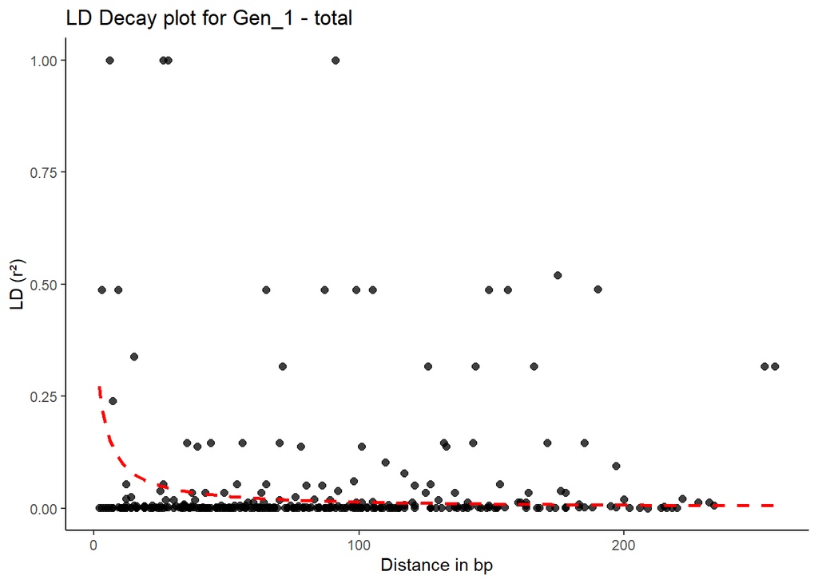

```r
# Decay plot

ggplot(ld_long, aes(x = distance, y = value)) +
  geom_point(aes(y = value), size = 2,alpha = 0.5, color = "black") +  # Raw LD data
  geom_line(aes(y = hill_weir_predicted), color = "red", size = 1, linetype = "dashed") +  # Hill-Weir
  theme_classic() +
  labs(title = "LD Decay plot for Gen_1 - total",
       x = "Distance in bp",
       y = "LD (r²)")
```

*LD Decay Plots:* Wykres dla Genu 1 populacji total.

Innym sposobem przedstawienia LD jest **heatmap wartości r²** pomiędzy wszystkimi parami miejsc polimorficznych. Możemy stworzyć taką mapę LD np. dla genu, który wykazał interesujące wzorce LD — na przykład **Gen_1**.

Każda komórka w mapie przedstawia wartość **r²** między dwiema pozycjami w sekwencji a intensywność koloru oddaje wartość r².

Możemy w tym celu użyć funkcji **`LDmap()`** z pakietu **pegas**:

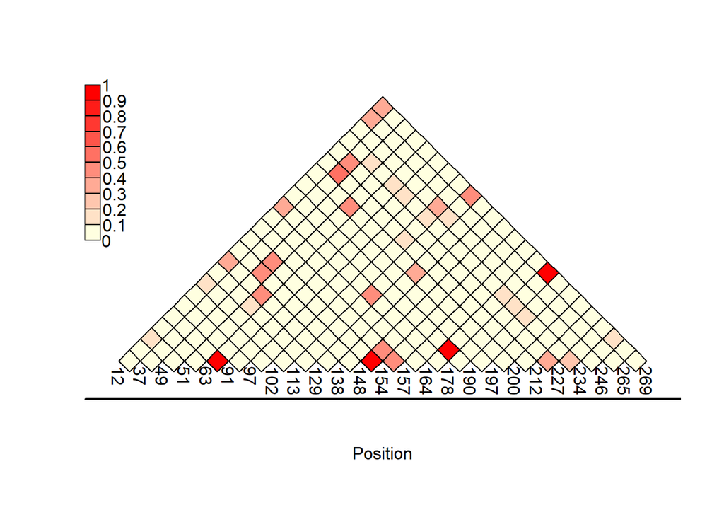

```r
# Plot of LD

# visualization of correletion between different loci
bks <- seq(0, 1, 0.1)                               # setting breaks for legends
LDmap(LD_results_R2, bks, scale.legend = 1,border = T) # producing graph
```

**Ćwiczenie 3** - Wykonaj analizę linkage disequilibrium (LD) dla każdego genu i populacji. Przedstaw na wykresach LD decay plot zależność pomiędzy LD (r²) i odległością między miejscami zmiennymi. Dla każdego wykresu podaj, czy korelacja między loci jest wysoka, niska, czy średnia, w porównaniu do innych genów/ populacji.